# Bellabeat Case Study with SQL and R

### 🔍 Data Exploration

**1.** Now that I’ve cleaned the data needed for analysis, I will load the datasets (in CSV format) into RStudio, along with the necessary packages, to begin the exploration process.

```r
# Load necessary packages
suppressPackageStartupMessages(library(tidyverse))

# Load datasets
daily_activity <- read_csv("dailyactivity.csv")
hourly_intensities <- read_csv("hourlyintensities.csv")
hourly_calories <- read_csv("hourlycalories.csv")
hourly_steps <- read_csv("hourlysteps.csv")
sleep_day <- read_csv("sleepday.csv")
```

**2.** I want to determine the number of unique users, as many IDs appear multiple times.

```r
# Creating a list of datasets
datasets <- list(daily_activity, hourly_intensities, hourly_calories, hourly_steps, sleep_day)

# Directly printing the distinct counts for each dataset
sapply(datasets, function(df) n_distinct(df$Id))
```

**Output:**

```r
[1] 33 33 33 33 24
```

**3.** After confirming that certain datasets have the same number of unique IDs, I want to check if they also contain the same number of entries to ensure compatibility for merging, helping to organize and streamline the datasets.

```r
# Get the number of rows for each dataset
sapply(datasets, nrow)
```

**Output:**

```r
[1] 940 22099 22099 22099 413
```

**4.** I will merge `hourly_intensities`, `hourly_calories`, and `hourly_steps` into a new dataset named `hourly_merged` because they are the only datasets with matching unique ID counts and the same number of entries, making them suitable for merging.

```r
# Merging hourly_intensities and hourly_calories
hourly_merged <- merge(hourly_intensities, hourly_calories, by = c("Id", "ActivityDate", "ActivityHour"))

# Merging the result with hourly_steps
hourly_merged <- merge(hourly_merged, hourly_steps, by = c("Id", "ActivityDate", "ActivityHour"))

# The resulting dataset is named hourly_merged
```

*Note:* The `merge()` function in R can only combine two datasets at a time, which is why the merging process requires two steps when working with three datasets. (While advanced coding can achieve the output in a single step, I’m choosing to stick with the basic approach. 😔)

**Output:**

```r
# Merged dataset from "hourly_intensities", "hourly_calories", and "hourly_steps"
| Row | Id         | ActivityDate | ActivityHour | TotalIntensity | AverageIntensity | Calories | StepTotal |
|-----|------------|--------------|--------------|----------------|------------------|----------|-----------|
| 1   | 1503960366 | 4/12/2016    | 00:00:00     | 20             | 0.33             | 81       | 373       |
| 2   | 1503960366 | 4/12/2016    | 01:00:00     | 8              | 0.13             | 61       | 160       |
| 3   | 1503960366 | 4/12/2016    | 02:00:00     | 7              | 0.12             | 59       | 151       |
| 4   | 1503960366 | 4/12/2016    | 03:00:00     | 0              | 0.00             | 47       | 0         |
| 5   | 1503960366 | 4/12/2016    | 04:00:00     | 0              | 0.00             | 48       | 0         |
```

*Note:* The table above display only the first 5 rows for visualization purposes.

**5.** Let’s return to the `dailyactivity` dataset and examine any patterns and trends within it:

```r
## Part 1:
| Id         | ActivityDate | TotalSteps | TotalDistance | TrackerDistance | VeryActiveDistance  |
|------------|--------------|------------|---------------|-----------------|---------------------|
| 1503960366 | 2016-04-12   | 13162      | 8.50          | 8.50            | 1.88                |
| 1503960366 | 2016-04-13   | 10735      | 6.97          | 6.97            | 1.57                |
| 1503960366 | 2016-04-14   | 10460      | 6.74          | 6.74            | 2.44                |
| 1503960366 | 2016-04-15   | 9762       | 6.28          | 6.28            | 2.14                |
| 1503960366 | 2016-04-16   | 12669      | 8.16          | 8.16            | 2.71                |

## Part 2:
| Id         | ModeratelyActiveDistance | LightActiveDistance | VeryActiveMinutes | FairlyActiveMinutes |
|------------|--------------------------|---------------------|-------------------|---------------------|
| 1503960366 | 0.55                     | 6.06                | 25                | 13                  |
| 1503960366 | 0.69                     | 4.71                | 21                | 19                  |
| 1503960366 | 0.40                     | 3.91                | 30                | 11                  |
| 1503960366 | 1.26                     | 2.83                | 29                | 34                  |
| 1503960366 | 0.41                     | 5.04                | 36                | 10                  |

## Part 3:
| Id         | SedentaryMinutes | Calories |
|------------|------------------|----------|
| 1503960366 | 728              | 1985     |
| 1503960366 | 776              | 1797     |
| 1503960366 | 1218             | 1776     |
| 1503960366 | 726              | 1745     |
| 1503960366 | 773              | 1863     |
```

*Note:* The table above shows only the first 5 rows for a single ID number from the `dailyactivity` dataset.

- 5a. Let’s perform a quick overview of the three datasets—`daily_activity`, `hourly_merged`, and `sleep_day`—using the `summary()` function in R.

```r
summary(daily_activity[c("TotalSteps", "TotalDistance", "TrackerDistance", "VeryActiveDistance", "ModeratelyActiveDistance", "LightActiveDistance", "VeryActiveMinutes", "FairlyActiveMinutes", "SedentaryMinutes", "Calories")])
```

**Output:**

```r
# "daily_activity" Dataset Summary
| Variable                    | Min.   | 1st Qu. | Median | Mean  | 3rd Qu. | Max.   |
|-----------------------------|--------|---------|--------|-------|---------|--------|
| **TotalSteps**              | 0      | 3790    | 7406   | 7638  | 10727   | 36019  |
| **TotalDistance**           | 0.000  | 2.620   | 5.245  | 5.490 | 7.713   | 28.030 |
| **TrackerDistance**         | 0.000  | 2.620   | 5.245  | 5.475 | 7.710   | 28.030 |
| **VeryActiveDistance**      | 0.000  | 0.000   | 0.210  | 1.503 | 2.053   | 21.920 |
| **ModeratelyActiveDistance**| 0.000  | 0.000   | 0.240  | 0.568 | 0.800   | 6.480  |
| **LightActiveDistance**     | 0.000  | 1.945   | 3.365  | 3.341 | 4.782   | 10.710 |
| **VeryActiveMinutes**       | 0.00   | 0.00    | 4.00   | 21.16 | 32.00   | 210.00 |
| **FairlyActiveMinutes**     | 0.00   | 0.00    | 6.00   | 13.56 | 19.00   | 143.00 |
| **SedentaryMinutes**        | 0.0    | 729.8   | 1057.5 | 991.2 | 1229.5  | 1440.0 |
| **Calories**                | 0      | 1828    | 2134   | 2304  | 2793    | 4900   |
```

*Note:* I excluded the `Id` and `ActivityDate` columns from the summary since they are not necessary.

```r
summary(hourly_merged[c("TotalIntensity", "AverageIntensity", "Calories", "StepTotal")])
```

**Output:**

```r
# "hourly_merged" Dataset Summary
| Variable              | Min.   | 1st Qu. | Median | Mean  | 3rd Qu. | Max.   |
|-----------------------|--------|---------|--------|-------|---------|--------|
| **TotalIntensity**    | 0.00   | 0.00    | 3.00   | 12.04 | 16.00   | 180.00 |
| **AverageIntensity**  | 0.0000 | 0.0000  | 0.0500 | 0.2007| 0.2700  | 3.0000 |
| **Calories**          | 42.00  | 63.00   | 83.00  | 97.39 | 108.00  | 948.00 |
| **StepTotal**         | 0.0    | 0.0     | 40.0   | 320.2 | 357.0   | 10554.0|
```

*Note:* I excluded the `Id`, `ActivityDate`, and `ActivityHour` columns from the summary since they are not necessary.

```r
summary(sleep_day[c("TotalSleepRecords", "TotalMinutesAsleep", "TotalTimeInBed")])
```

**Output:**

```r
# "sleep_day" Dataset Summary
| Variable               | Min.   | 1st Qu. | Median | Mean  | 3rd Qu. | Max.   |
|------------------------|--------|---------|--------|-------|---------|--------|
| **TotalSleepRecords**  | 1.00   | 1.00    | 1.00   | 1.12  | 1.00    | 3.00   |
| **TotalMinutesAsleep** | 58.00  | 361.00  | 433.00 | 419.5 | 490.00  | 796.00 |
| **TotalTimeInBed**     | 61.00  | 403.00  | 463.00 | 458.6 | 526.00  | 961.00 |
```

**6.** Here are the key takeaways from the summary data above:

- On average, users take 7,638 steps per day, which is below the CDC’s recommended 8,000 to 10,000 steps for maintaining good health.
- Users primarily engage in light physical activity, with this being the most common form of exercise compared to very active or moderately active sessions.
- Users spend most of their time sedentary, averaging 991.2 minutes, and participate minimally in very active (21.16 minutes) or moderately active (13.56 minutes) activities.
- The average calorie consumption is 2,304, which aligns with the general daily calorie requirements of 1,600 to 2,400 for women and 2,000 to 3,000 for men, as outlined in the Dietary Guidelines for Americans 2020-2025.
- On average, users burn 97.39 calories per hour.
- Users take an average of 320.2 steps per hour.
- Sleep duration ranges from 58 to 796 minutes, with an average of 419.5 minutes (around 7 hours).
- The total time spent in bed varies from 61 to 961 minutes, with an average of 458.6 minutes (7.64 hours), which includes both sleep and wake periods.

### 📈 Data Visualization

**1.** I want to determine if the number of steps taken and the total distance covered by the user affect the calories burned, as this data will be important for our recommendations later.

```r
# Total Steps vs. Calories
ggplot(data = daily_activity, aes(x = TotalSteps, y = Calories)) +
  geom_point(color = "skyblue", size = 2, alpha = 0.7) +
  geom_smooth(method = "lm", color = "darkblue", se = FALSE) +
  labs(title = "Total Steps vs. Calories", x = "Total Steps", y = "Calories") +
  theme_minimal(base_size = 14) +
  theme(
    plot.title = element_text(hjust = 0.5, size = 16, face = "bold"),
    axis.title = element_text(size = 12, face = "bold"),
    axis.text = element_text(size = 10)
  )

# Total Distance vs. Calories
ggplot(data = daily_activity, aes(x = TotalDistance, y = Calories)) +
  geom_point(color = "lightgreen", size = 3, alpha = 0.8) +
  geom_smooth(method = "lm", color = "darkgreen", se = FALSE) +
  labs(title = "Total Distance vs. Calories", x = "Total Distance ", y = "Calories") +
  theme_minimal(base_size = 14) +
  theme(
    plot.title = element_text(hjust = 0.5, size = 18, face = "italic"),
    axis.title = element_text(size = 14, face = "bold"),
    axis.text = element_text(size = 12, color = "black"),
    panel.grid.major = element_line(color = "gray", linetype = "dashed"),
    panel.grid.minor = element_blank()
  )
```

**Output:**

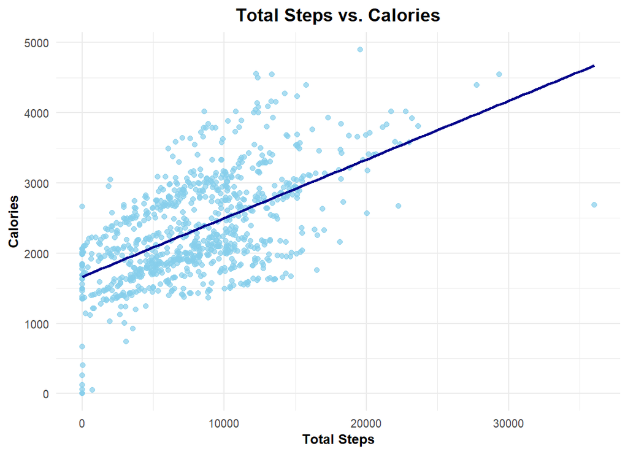

[figure not shown]

The scatterplot above shows a positive correlation between the number of steps taken, the total distance covered, and calories burned, indicating that **as both the number of steps and distance increase, the calories burned also increase.**

**2.** I want to visualize the distance covered by users based on the `VeryActiveDistance`, `ModeratelyActiveDistance`, and `LightActiveDistance` columns.

```r
# Transform the data into a long format and remove rows with missing or zero values.
daily_activity_filtered <- daily_activity %>%
  pivot_longer(cols = c(VeryActiveDistance, ModeratelyActiveDistance, LightActiveDistance),
               names_to = "ActivityLevel",
               values_to = "Distance") %>%
  filter_all(all_vars(!is.na(.) & . != 0))

# Visualize Distribution of Active Distance
ggplot(daily_activity_filtered, aes(x = Distance, fill = ActiveDistance)) +
  geom_histogram(bins = 30, position = "dodge", alpha = 0.7) +
  facet_wrap(~ ActiveDistance, scales = "free_x") +
  theme_minimal() +
  labs(title = "Distribution of Active Distance (Excluding Zeros)",
       x = "Distance",
       y = "Frequency") +
  scale_fill_brewer(palette = "Set1")
```

**Output:**

[figure not shown]

The histogram above shows that **a greater number of users cover more distance under `LightActiveDistance`.**

**3.** I aim to estimate the time it takes for a user to fall asleep while in bed. Due to data limitations, I assume that `TimeAwakeBeforeSleep` — calculated as the difference between `TotalTimeInBed` and `TotalMinutesAsleep` — represents the time spent in bed before falling asleep, excluding wake periods or other factors.

```r
# Calculate time spent awake in bed before falling asleep
sleep_day$TimeAwakeBeforeSleep <- sleep_day$TotalTimeInBed - sleep_day$TotalMinutesAsleep

# Visualize Time Spent Awake in Bed Before Falling Asleep
ggplot(sleep_day, aes(x = TimeAwakeBeforeSleep)) +
  geom_histogram(binwidth = 10, fill = "skyblue", color = "darkblue", alpha = 0.7) +
  labs(
    title = "Time Spent Awake in Bed Before Falling Asleep",
    x = "Time Awake Before Sleep (minutes)",
    y = "Frequency"
  ) +
  theme_minimal(base_size = 14) +
  theme(
    plot.title = element_text(hjust = 0.5, size = 16, face = "bold"),
    axis.title = element_text(size = 12, face = "bold"),
    axis.text = element_text(size = 10)
  )
```

**Output:**

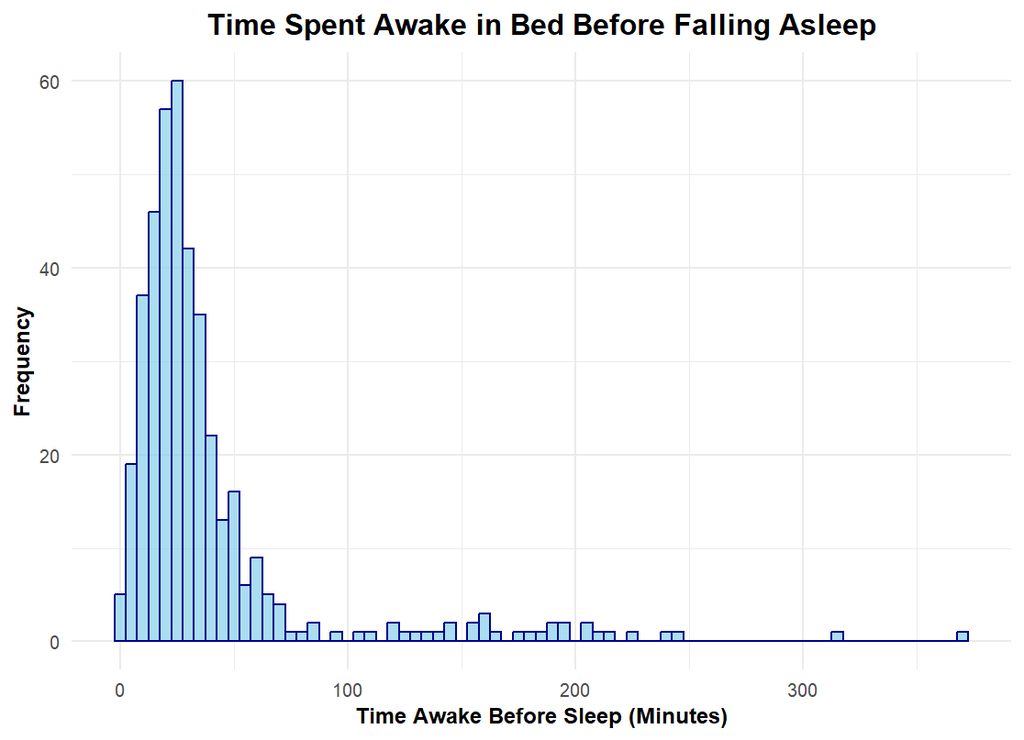

## **Final Insights 💡**

### 🎯 Recommendations

Let’s revisit the business tasks provided by our stakeholders, which are:

1. What are some trends in smart device usage?
2. How could these trends apply to Bellabeat customers?
3. How can these trends help influence Bellabeat marketing strategy?

### 3. How can these trends help influence Bellabeat marketing strategy?

These trends suggests that Bellabeat can tailor their marketing strategy to show that even light physical activity can lead to an overall healthier life, as most of the users in the data appear to be less suited for moderate or high-intensity fitness. By highlighting the impact a distance metric has on the steps they take and calories they burn, and providing attainable goals in the form of milestones and streaks, users are motivated to achieve their goals in fitness. In idle periods before sleep, they could include how users are sleeping and advice on how to improve, or even soothing sounds to help them rest better. Meanwhile, daily goal trackers will keep users engaged, prevent them from going off course, and provide them enough time to make adjustments if necessary.

## **FIN 🙇🏻‍♂️**